# Skiver Results: pacbio train

- Show All Code
- Hide All Code
- View Source

```python
SAMPLE_NAME = "pacbio"
SPLIT_NAME = "train"
RESULT_DIR = "../../skiver_run/pacbio/train"
```

## 1 Setup

```python
from __future__ import annotations

import os
import math
import gzip
from collections import Counter, defaultdict
from pathlib import Path

os.environ.setdefault("MPLCONFIGDIR", "/private/tmp/skiver-mpl-cache")

import matplotlib.pyplot as plt
import matplotlib.ticker as mticker
import numpy as np
import pandas as pd
import seaborn as sns
from IPython.display import display

sns.set_theme(style="whitegrid", palette="muted")
plt.rcParams["figure.dpi"] = 120

RESULT_DIR = Path(RESULT_DIR)
PASSES_FILTER_ONLY = True
BASE_CHUNKSIZE = 1_000_000
MAX_AUTOCORR_LAG = 6
FASTQ_SAMPLE_READS = 1_000
QUALITY_MAX_BASES_PER_READ = 2_000
MAX_QUALITY_AUTOCORR_LAG = 200
QUALITY_AUTOCORR_DECAY_WINDOW = 10

SUMMARY_SUFFIXES = {
    "error_rate": ".summary_error_rate.csv",
    "hazard": ".hazard_rate.csv",
    "phred": ".summary_phred.csv",
    "spectrum": ".summary_error_spectrum.csv",
    "spectrum_t": ".summary_error_spectrum_dependence_on_t.csv",
    "read_position": ".summary_read_position.csv",
    "kvmer": ".kvmer.csv",
    "base": ".base_observations.tsv",
}


def discover_prefixes(result_dir: Path) -> list[Path]:
    files = sorted(result_dir.glob(f"*{SUMMARY_SUFFIXES['error_rate']}"))
    return [Path(str(path).removesuffix(SUMMARY_SUFFIXES["error_rate"])) for path in files]


PREFIXES = discover_prefixes(RESULT_DIR)
if not PREFIXES:
    raise FileNotFoundError(f"No Skiver summary_error_rate.csv files found in {RESULT_DIR}")

print(f"Sample: {SAMPLE_NAME}")
print(f"Split: {SPLIT_NAME}")
print(f"Result directory: {RESULT_DIR.resolve()}")
print("Prefixes:")
for prefix in PREFIXES:
    print(f"  - {prefix.name}")
```

```
Sample: pacbio
Split: train
Result directory: /Users/timrozday/Documents/skiver_run/pacbio/train
Prefixes:
  - ERR12117707_train
```

```python
def path_for(prefix: Path, kind: str) -> Path:
    return Path(f"{prefix}{SUMMARY_SUFFIXES[kind]}")


def read_csv(prefix: Path, kind: str) -> pd.DataFrame:
    path = path_for(prefix, kind)
    if not path.exists():
        raise FileNotFoundError(path)
    return pd.read_csv(path)


def classify_op(op: str) -> str:
    if op.startswith("->"):
        return "Insertion"
    if op.endswith(">-"):
        return "Deletion"
    if ">" in op:
        return "Substitution"
    return "Other"


def fmt_pct(x: float) -> str:
    return f"{x:.4%}"


def parse_interval(value: object) -> tuple[float, float] | tuple[None, None]:
    if not isinstance(value, str) or "~" not in value:
        return None, None
    lo, hi = value.split("~", 1)
    return float(lo), float(hi)


file_rows = []
for prefix in PREFIXES:
    for kind in SUMMARY_SUFFIXES:
        path = path_for(prefix, kind)
        file_rows.append({
            "prefix": prefix.name,
            "file": path.name,
            "kind": kind,
            "exists": path.exists(),
            "size_mb": path.stat().st_size / 1_000_000 if path.exists() else np.nan,
        })

file_df = pd.DataFrame(file_rows)
display(file_df)
```

|  | prefix | file | kind | exists | size_mb |
| --- | --- | --- | --- | --- | --- |
| 0 | ERR12117707_train | ERR12117707_train.summary_error_rate.csv | error_rate | True | 0.000449 |
| 1 | ERR12117707_train | ERR12117707_train.hazard_rate.csv | hazard | True | 0.000580 |
| 2 | ERR12117707_train | ERR12117707_train.summary_phred.csv | phred | True | 0.002827 |
| 3 | ERR12117707_train | ERR12117707_train.summary_error_spectrum.csv | spectrum | True | 0.004489 |
| 4 | ERR12117707_train | ERR12117707_train.summary_error_spectrum_depen... | spectrum_t | True | 0.011802 |
| 5 | ERR12117707_train | ERR12117707_train.summary_read_position.csv | read_position | True | 0.933360 |
| 6 | ERR12117707_train | ERR12117707_train.kvmer.csv | kvmer | True | 38.983785 |
| 7 | ERR12117707_train | ERR12117707_train.base_observations.tsv | base | True | 2350.259299 |

## 2 Scalar Error Summary

This section uses `*.summary_error_rate.csv`, one row per Skiver prefix. It reports the fitted per-base error rate, the effective error rate after the survival-model correction, Weibull parameters, and typical coverage. These values are the highest-level summary of whether a sample/split behaves like a low-error or high-error sequencing run.

```python
summary_rows = []
for prefix in PREFIXES:
    df = read_csv(prefix, "error_rate")
    row = df.iloc[0].to_dict()
    row["prefix"] = prefix.name
    summary_rows.append(row)

summary_df = pd.DataFrame(summary_rows)
cols = [
    "prefix",
    "per_base_error_rate",
    "effective_error_rate",
    "lambda",
    "beta",
    "key_median_coverage",
    "true_median_coverage",
]
display(summary_df[cols])
```

|  | prefix | per_base_error_rate | effective_error_rate | lambda | beta | key_median_coverage | true_median_coverage |
| --- | --- | --- | --- | --- | --- | --- | --- |
| 0 | ERR12117707_train | 0.002922 | 0.001494 | 0.002926 | 0.903342 | 13.0 | 13.609043 |

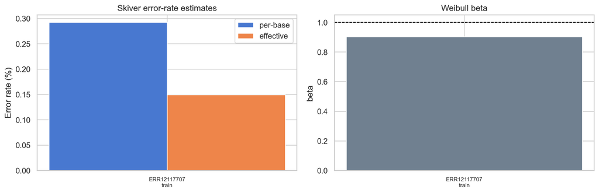

```python
fig, axes = plt.subplots(1, 2, figsize=(12, 4))

x = np.arange(len(summary_df))
labels = summary_df["prefix"].str.replace("_", "\n", regex=False)

axes[0].bar(x - 0.18, summary_df["per_base_error_rate"] * 100, width=0.36, label="per-base")
axes[0].bar(x + 0.18, summary_df["effective_error_rate"] * 100, width=0.36, label="effective")
axes[0].set_xticks(x)
axes[0].set_xticklabels(labels, rotation=0, fontsize=8)
axes[0].set_ylabel("Error rate (%)")
axes[0].set_title("Skiver error-rate estimates")
axes[0].legend()

axes[1].bar(x, summary_df["beta"], color="slategray")
axes[1].axhline(1.0, color="black", linestyle="--", linewidth=1)
axes[1].set_xticks(x)
axes[1].set_xticklabels(labels, rotation=0, fontsize=8)
axes[1].set_ylabel("beta")
axes[1].set_title("Weibull beta")

plt.tight_layout()
plt.show()
```

## 3 Hazard And Survival

This section uses `*.hazard_rate.csv`. The hazard ratio is the observed probability that the first disagreement with the consensus appears at value-window position `t`, conditional on no earlier disagreement. The survival curve is the cumulative probability of remaining error-free across the reported value window, so strong position effects show up as sharp drops.

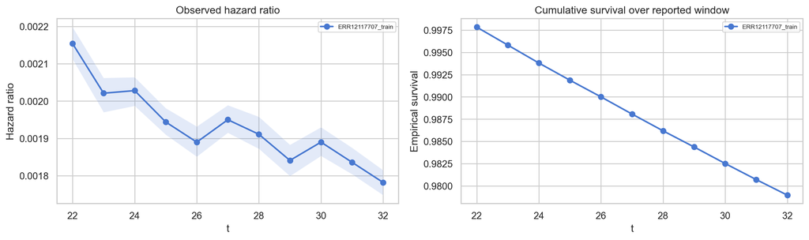

```python
fig, axes = plt.subplots(1, 2, figsize=(13, 4))

for prefix in PREFIXES:
    hazard = read_csv(prefix, "hazard")
    axes[0].plot(hazard["t"], hazard["hazard_ratio"], marker="o", linewidth=1.8, label=prefix.name)
    if {"5th_percentile", "95th_percentile"}.issubset(hazard.columns):
        axes[0].fill_between(
            hazard["t"],
            hazard["5th_percentile"],
            hazard["95th_percentile"],
            alpha=0.15,
        )

    survival = (1.0 - hazard["hazard_ratio"]).cumprod()
    axes[1].plot(hazard["t"], survival, marker="o", linewidth=1.8, label=prefix.name)

axes[0].set_xlabel("t")
axes[0].set_ylabel("Hazard ratio")
axes[0].set_title("Observed hazard ratio")
axes[0].legend(fontsize=7)

axes[1].set_xlabel("t")
axes[1].set_ylabel("Empirical survival")
axes[1].set_title("Cumulative survival over reported window")
axes[1].legend(fontsize=7)

plt.tight_layout()
plt.show()
```

## 4 Base Observations

This section streams `*.base_observations.tsv`, which contains one row per value-window base aligned against the inferred consensus. It is the most direct observation-level view of errors: the position plot shows where errors occur inside the value window, the sequence-length plot checks the emitted alignment lengths, and the matrix shows which consensus bases are observed as which alternatives.

```python
BASES5 = ["A", "C", "G", "T", "-"]
REPEAT_CONTEXTS = [str(i) for i in range(1, 11)]
HOMOPOLYMER_ERROR_CLASSES = ["Insertion", "Deletion", "Substitution"]


def repeat_context_label(length: int) -> str | None:
    length = max(length, 1)
    if length <= 10:
        return str(length)
    return None


def homopolymer_context_dataframe(state: dict) -> pd.DataFrame:
    rows = []
    for context in REPEAT_CONTEXTS:
        opportunities = state["opportunities"][context]
        row = {
            "repeat_context": context,
            "opportunities": opportunities,
        }
        total_errors = 0
        for error_class in HOMOPOLYMER_ERROR_CLASSES:
            count = state["errors"][context][error_class]
            total_errors += count
            row[f"{error_class.lower()}_count"] = count
            row[f"{error_class.lower()}_rate"] = count / opportunities if opportunities else np.nan
        row["all_error_count"] = total_errors
        row["all_error_rate"] = total_errors / opportunities if opportunities else np.nan
        rows.append(row)

    return pd.DataFrame(rows)


def finalize_homopolymer_sequence(rows: list[tuple[str, str, str]], state: dict) -> None:
    if not rows:
        return

    run_base = None
    run_length = 0

    for true_base, obs_base, prev_base in rows:
        if true_base != "-":
            if run_base is None:
                run_base = true_base
                run_length = 2 if prev_base == true_base else 1
            elif true_base == run_base:
                run_length += 1
            else:
                run_base = true_base
                run_length = 1

            context = repeat_context_label(run_length)
            if context is not None:
                state["opportunities"][context] += 1
                if obs_base == "-":
                    state["errors"][context]["Deletion"] += 1
                elif obs_base != true_base:
                    state["errors"][context]["Substitution"] += 1
            continue

        if obs_base == "-":
            continue
        if run_base is None:
            insertion_run_length = 2 if obs_base == prev_base else 1
        else:
            insertion_run_length = run_length + 1 if obs_base == run_base else 1
        context = repeat_context_label(insertion_run_length)
        if context is not None:
            state["errors"][context]["Insertion"] += 1


def update_homopolymer_sequences(groups: pd.DataFrame, state: dict) -> None:
    if groups.empty:
        return

    items = [
        (obs_id, list(zip(row["true_base"], row["obs_base"], row["prev_base"])))
        for obs_id, row in groups.iterrows()
    ]
    if state["obs_id"] is not None:
        first_id, first_rows = items[0]
        if first_id == state["obs_id"]:
            state["rows"].extend(first_rows)
            items = items[1:]
        else:
            finalize_homopolymer_sequence(state["rows"], state)
            state["obs_id"] = None
            state["rows"] = []

    if not items:
        return

    for obs_id, rows in items[:-1]:
        finalize_homopolymer_sequence(rows, state)

    state["obs_id"], state["rows"] = items[-1]


def finalize_error_sequence(errors: list[bool], state: dict) -> None:
    if not errors:
        return

    num_errors = int(np.sum(errors))
    state["error_count_dist"][min(num_errors, 3)] += 1

    arr = np.asarray(errors, dtype=bool)
    n = len(arr)
    for lag in range(1, MAX_AUTOCORR_LAG + 1):
        if n <= lag:
            continue

        left = arr[:-lag]
        right = arr[lag:]
        pair_count = len(left)
        left_errors = int(left.sum())
        right_errors = int(right.sum())
        both_errors = int((left & right).sum())

        state["lag_pairs"][lag] += pair_count
        state["lag_left_errors"][lag] += left_errors
        state["lag_right_errors"][lag] += right_errors
        state["lag_both_errors"][lag] += both_errors


def update_error_sequences(groups: pd.Series, state: dict) -> None:
    if groups.empty:
        return

    items = list(groups.items())
    if state["obs_id"] is not None:
        first_id, first_errors = items[0]
        if first_id == state["obs_id"]:
            state["errors"].extend(bool(x) for x in first_errors)
            items = items[1:]
        else:
            finalize_error_sequence(state["errors"], state)
            state["obs_id"] = None
            state["errors"] = []

    if not items:
        return

    for obs_id, errors in items[:-1]:
        finalize_error_sequence([bool(x) for x in errors], state)

    state["obs_id"], state["errors"] = items[-1][0], [bool(x) for x in items[-1][1]]


def autocorr_dataframe(state: dict) -> pd.DataFrame:
    rows = []
    for lag in range(1, MAX_AUTOCORR_LAG + 1):
        pairs = state["lag_pairs"][lag]
        left = state["lag_left_errors"][lag]
        right = state["lag_right_errors"][lag]
        both = state["lag_both_errors"][lag]

        if pairs == 0:
            rows.append({
                "lag": lag,
                "pairs": 0,
                "both_errors": 0,
                "joint_error_rate": np.nan,
                "expected_joint_error_rate": np.nan,
                "enrichment": np.nan,
                "phi": np.nan,
            })
            continue

        p_left = left / pairs
        p_right = right / pairs
        observed = both / pairs
        expected = p_left * p_right
        n11 = both
        n10 = left - both
        n01 = right - both
        n00 = pairs - n11 - n10 - n01
        denom = math.sqrt(float((n11 + n10) * (n01 + n00) * (n11 + n01) * (n10 + n00)))
        phi = (n11 * n00 - n10 * n01) / denom if denom else np.nan

        rows.append({
            "lag": lag,
            "pairs": pairs,
            "both_errors": both,
            "joint_error_rate": observed,
            "expected_joint_error_rate": expected,
            "enrichment": observed / expected if expected else np.nan,
            "phi": phi,
        })

    return pd.DataFrame(rows)


def update_sequence_lengths(groups: pd.Series, state: dict, counter: Counter) -> None:
    if groups.empty:
        return

    items = list(groups.items())
    if state["obs_id"] is not None:
        first_id, first_count = items[0]
        if first_id == state["obs_id"]:
            state["count"] += int(first_count)
            items = items[1:]
        else:
            counter[state["count"]] += 1
            state["obs_id"] = None
            state["count"] = 0

    if not items:
        return

    for obs_id, count in items[:-1]:
        counter[int(count)] += 1

    state["obs_id"], state["count"] = items[-1][0], int(items[-1][1])


def aggregate_base_observations(prefix: Path, passes_filter_only: bool = True) -> dict:
    path = path_for(prefix, "base")
    if not path.exists():
        return {"prefix": prefix.name, "available": False}

    usecols = ["obs_id", "t", "true_base", "obs_base", "prev_base", "phred", "passes_filter"]
    t_counts = defaultdict(int)
    t_errors = defaultdict(int)
    subst = pd.DataFrame(0, index=BASES5, columns=BASES5, dtype=np.int64)
    seq_lengths = Counter()
    length_state = {"obs_id": None, "count": 0}
    autocorr_state = {
        "obs_id": None,
        "errors": [],
        "error_count_dist": Counter(),
        "lag_pairs": defaultdict(int),
        "lag_left_errors": defaultdict(int),
        "lag_right_errors": defaultdict(int),
        "lag_both_errors": defaultdict(int),
    }
    homopolymer_state = {
        "obs_id": None,
        "rows": [],
        "opportunities": defaultdict(int),
        "errors": defaultdict(lambda: defaultdict(int)),
    }
    total = 0
    errors = 0

    chunks = pd.read_csv(path, sep="\t", usecols=usecols, chunksize=BASE_CHUNKSIZE)
    for chunk in chunks:
        if passes_filter_only:
            chunk = chunk[chunk["passes_filter"] == True]
        if chunk.empty:
            continue

        is_error = chunk["true_base"] != chunk["obs_base"]
        total += len(chunk)
        errors += int(is_error.sum())

        by_t_total = chunk.groupby("t", sort=True).size()
        by_t_error = chunk.loc[is_error].groupby("t", sort=True).size()
        for t, count in by_t_total.items():
            t_counts[int(t)] += int(count)
        for t, count in by_t_error.items():
            t_errors[int(t)] += int(count)

        matrix_chunk = pd.crosstab(
            chunk.loc[is_error, "true_base"],
            chunk.loc[is_error, "obs_base"],
        ).reindex(index=BASES5, columns=BASES5, fill_value=0)
        subst += matrix_chunk

        obs_groups = chunk.groupby("obs_id", sort=False).size()
        update_sequence_lengths(obs_groups, length_state, seq_lengths)

        error_groups = is_error.groupby(chunk["obs_id"], sort=False).agg(list)
        update_error_sequences(error_groups, autocorr_state)

        homopolymer_groups = chunk.groupby("obs_id", sort=False)[["true_base", "obs_base", "prev_base"]].agg(list)
        update_homopolymer_sequences(homopolymer_groups, homopolymer_state)

    if length_state["obs_id"] is not None:
        seq_lengths[length_state["count"]] += 1
    if autocorr_state["obs_id"] is not None:
        finalize_error_sequence(autocorr_state["errors"], autocorr_state)
    if homopolymer_state["obs_id"] is not None:
        finalize_homopolymer_sequence(homopolymer_state["rows"], homopolymer_state)

    pos_df = pd.DataFrame({
        "t": sorted(t_counts),
        "total": [t_counts[t] for t in sorted(t_counts)],
        "errors": [t_errors[t] for t in sorted(t_counts)],
    })
    pos_df["error_rate"] = pos_df["errors"] / pos_df["total"]

    return {
        "prefix": prefix.name,
        "available": True,
        "total": total,
        "errors": errors,
        "error_rate": errors / total if total else np.nan,
        "pos": pos_df,
        "subst": subst,
        "seq_lengths": seq_lengths,
        "error_count_dist": autocorr_state["error_count_dist"],
        "autocorr": autocorr_dataframe(autocorr_state),
        "homopolymer": homopolymer_context_dataframe(homopolymer_state),
    }


base_summaries = [
    aggregate_base_observations(prefix, passes_filter_only=PASSES_FILTER_ONLY)
    for prefix in PREFIXES
]

base_summary_df = pd.DataFrame([
    {
        "prefix": s["prefix"],
        "available": s["available"],
        "base_observations": s.get("total", 0),
        "errors": s.get("errors", 0),
        "observed_error_rate": s.get("error_rate", np.nan),
    }
    for s in base_summaries
])
display(base_summary_df)
```

|  | prefix | available | base_observations | errors | observed_error_rate |
| --- | --- | --- | --- | --- | --- |
| 0 | ERR12117707_train | True | 41672592 | 73956 | 0.001775 |

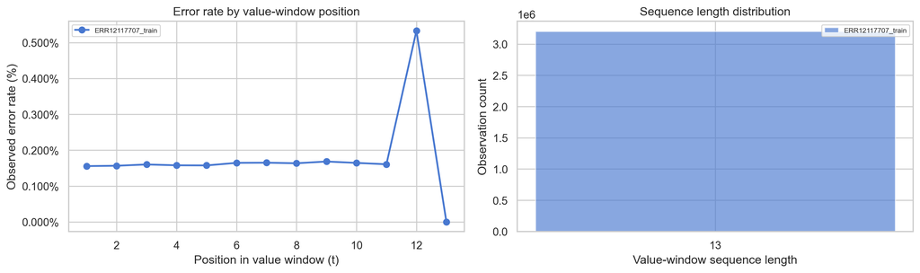

```python
fig, axes = plt.subplots(1, 2, figsize=(13, 4))

for summary in base_summaries:
    if not summary["available"]:
        continue
    pos = summary["pos"]
    axes[0].plot(pos["t"], pos["error_rate"] * 100, marker="o", linewidth=1.8, label=summary["prefix"])

    lengths = pd.DataFrame(
        {"length": list(summary["seq_lengths"].keys()), "count": list(summary["seq_lengths"].values())}
    ).sort_values("length")
    axes[1].bar(
        lengths["length"].astype(str),
        lengths["count"],
        alpha=0.65,
        label=summary["prefix"],
    )

axes[0].set_xlabel("Position in value window (t)")
axes[0].set_ylabel("Observed error rate (%)")
axes[0].set_title("Error rate by value-window position")
axes[0].yaxis.set_major_formatter(mticker.FormatStrFormatter("%.3f%%"))
axes[0].legend(fontsize=7)

axes[1].set_xlabel("Value-window sequence length")
axes[1].set_ylabel("Observation count")
axes[1].set_title("Sequence length distribution")
axes[1].legend(fontsize=7)

plt.tight_layout()
plt.show()
```

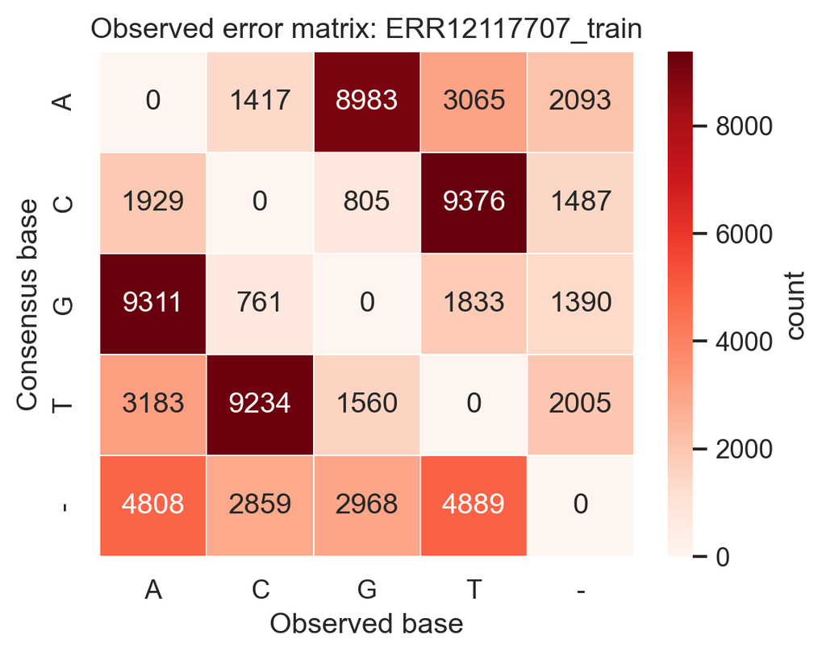

```python
for summary in base_summaries:
    if not summary["available"]:
        continue
    fig, ax = plt.subplots(figsize=(5, 4))
    sns.heatmap(
        summary["subst"],
        annot=True,
        fmt="d",
        cmap="Reds",
        linewidths=0.5,
        cbar_kws={"label": "count"},
        ax=ax,
    )
    ax.set_xlabel("Observed base")
    ax.set_ylabel("Consensus base")
    ax.set_title(f"Observed error matrix: {summary['prefix']}")
    plt.tight_layout()
    plt.show()
```

## 5 Error Autocorrelation

This section also uses `*.base_observations.tsv`. Each `obs_id` is converted to a binary sequence over value-window positions, where `1` means the observed base differs from the consensus. The lag analysis asks whether an error at one position makes another error nearby more common than expected from the marginal error rates; enrichment above `1` or positive phi correlation suggests clustering, which can be consistent with latent read-level or sequence-context factors.

```python
autocorr_tables = []
for summary in base_summaries:
    if not summary["available"]:
        continue
    autocorr = summary["autocorr"].copy()
    autocorr.insert(0, "prefix", summary["prefix"])
    autocorr_tables.append(autocorr)

if autocorr_tables:
    autocorr_df = pd.concat(autocorr_tables, ignore_index=True)
    display(autocorr_df)
else:
    autocorr_df = pd.DataFrame()
    print("No base observations available for autocorrelation analysis.")
```

|  | prefix | lag | pairs | both_errors | joint_error_rate | expected_joint_error_rate | enrichment | phi |
| --- | --- | --- | --- | --- | --- | --- | --- | --- |
| 0 | ERR12117707_train | 1 | 38466516 | 0 | 0.0 | 0.000003 | 0.0 | -0.001860 |
| 1 | ERR12117707_train | 2 | 35260973 | 0 | 0.0 | 0.000003 | 0.0 | -0.001713 |
| 2 | ERR12117707_train | 3 | 32055430 | 0 | 0.0 | 0.000003 | 0.0 | -0.001724 |
| 3 | ERR12117707_train | 4 | 28849887 | 0 | 0.0 | 0.000003 | 0.0 | -0.001735 |
| 4 | ERR12117707_train | 5 | 25644344 | 0 | 0.0 | 0.000003 | 0.0 | -0.001747 |
| 5 | ERR12117707_train | 6 | 22438801 | 0 | 0.0 | 0.000003 | 0.0 | -0.001761 |

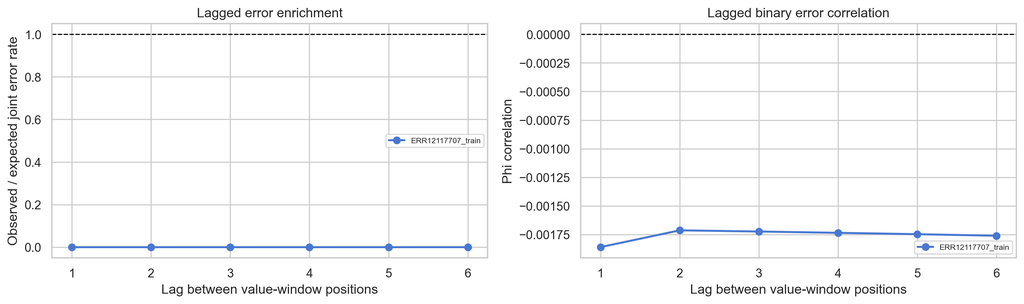

```python
if not autocorr_df.empty:
    fig, axes = plt.subplots(1, 2, figsize=(13, 4))
    for prefix, sub in autocorr_df.groupby("prefix"):
        axes[0].plot(sub["lag"], sub["enrichment"], marker="o", linewidth=1.8, label=prefix)
        axes[1].plot(sub["lag"], sub["phi"], marker="o", linewidth=1.8, label=prefix)

    axes[0].axhline(1.0, color="black", linestyle="--", linewidth=1)
    axes[0].set_xlabel("Lag between value-window positions")
    axes[0].set_ylabel("Observed / expected joint error rate")
    axes[0].set_title("Lagged error enrichment")
    axes[0].legend(fontsize=7)

    axes[1].axhline(0.0, color="black", linestyle="--", linewidth=1)
    axes[1].set_xlabel("Lag between value-window positions")
    axes[1].set_ylabel("Phi correlation")
    axes[1].set_title("Lagged binary error correlation")
    axes[1].legend(fontsize=7)

    plt.tight_layout()
    plt.show()
```

|  | prefix |
| --- | --- |
| 0 | ERR12117707_train |

|  | errors_per_sequence | count |
| --- | --- | --- |
| 0 | 0 | 3131587 |
| 1 | 1 | 73956 |
| 2 | 2 | 0 |
| 3 | >=3 | 0 |

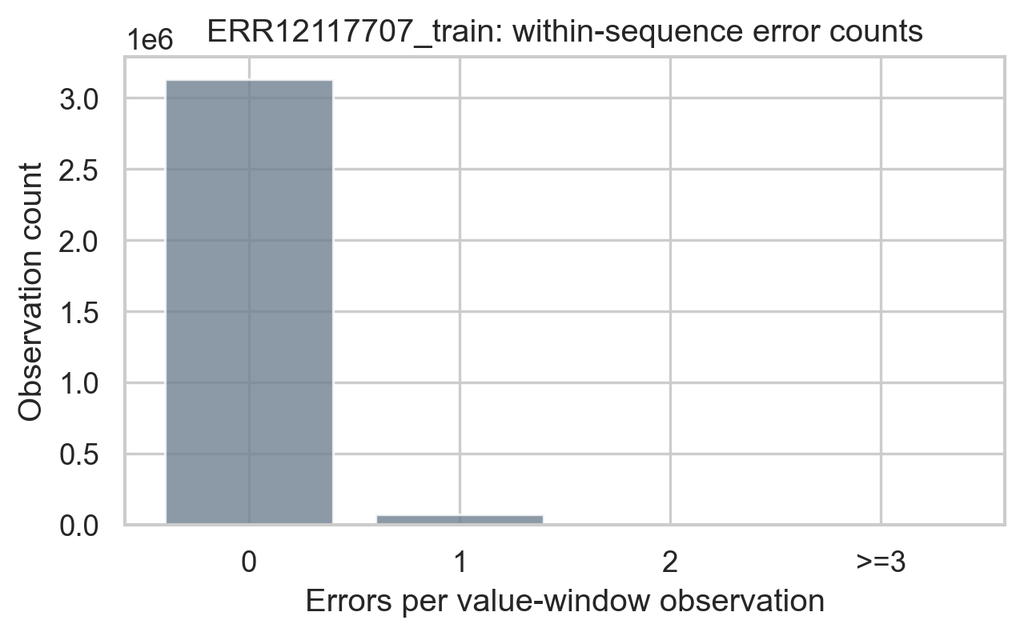

```python
for summary in base_summaries:
    if not summary["available"]:
        continue

    dist = summary["error_count_dist"]
    dist_df = pd.DataFrame({
        "errors_per_sequence": ["0", "1", "2", ">=3"],
        "count": [dist.get(0, 0), dist.get(1, 0), dist.get(2, 0), dist.get(3, 0)],
    })
    display(pd.DataFrame({"prefix": [summary["prefix"]]}))
    display(dist_df)

    fig, ax = plt.subplots(figsize=(5.5, 3.5))
    ax.bar(dist_df["errors_per_sequence"], dist_df["count"], color="slategray", alpha=0.8)
    ax.set_xlabel("Errors per value-window observation")
    ax.set_ylabel("Observation count")
    ax.set_title(f"{summary['prefix']}: within-sequence error counts")
    plt.tight_layout()
    plt.show()
```

## 6 Phred Calibration

This section uses `*.summary_phred.csv`. It compares the empirical error rate observed at each Phred score against the nominal probability implied by the Phred scale. Agreement with the dashed curve suggests well-calibrated base qualities; systematic offsets indicate over- or under-confident quality scores.

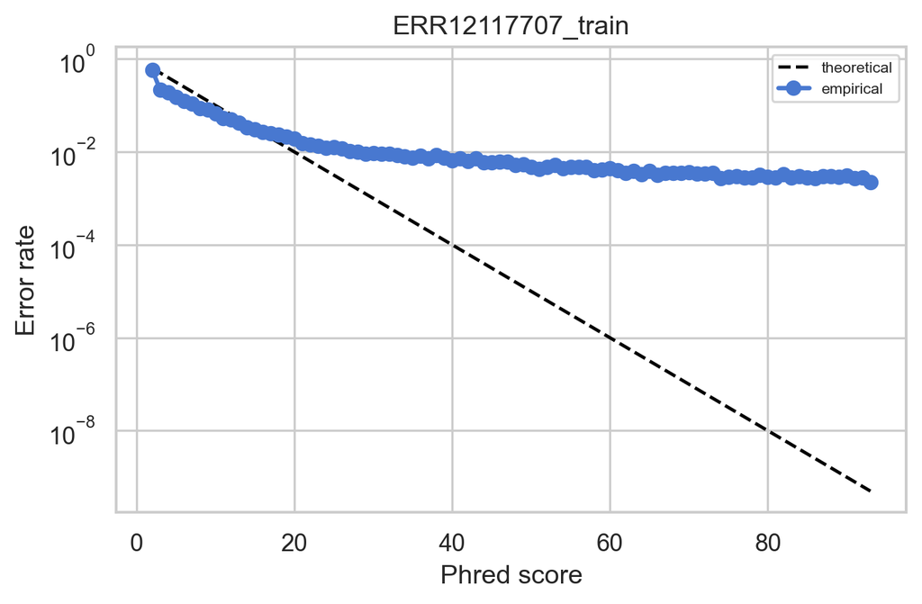

```python
fig, axes = plt.subplots(1, len(PREFIXES), figsize=(6 * len(PREFIXES), 4), squeeze=False)

for ax, prefix in zip(axes.ravel(), PREFIXES):
    phred = read_csv(prefix, "phred").copy()
    phred["num_total"] = phred["num_correct"] + phred["num_error"]
    phred = phred[phred["num_total"] > 0]

    if not phred.empty:
        q_theory = np.linspace(max(1, phred["qscore"].min()), phred["qscore"].max(), 300)
        ax.plot(q_theory, 10 ** (-q_theory / 10.0), color="black", linestyle="--", label="theoretical")
        ax.plot(phred["qscore"], phred["error_rate"], marker="o", linewidth=2, label="empirical")
        ax.set_yscale("log")
    ax.set_xlabel("Phred score")
    ax.set_ylabel("Error rate")
    ax.set_title(prefix.name)
    ax.legend(fontsize=7)

plt.tight_layout()
plt.show()
```

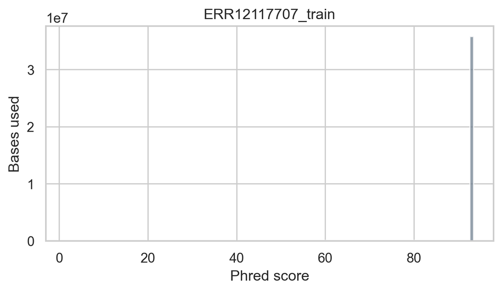

```python
fig, axes = plt.subplots(1, len(PREFIXES), figsize=(6 * len(PREFIXES), 3.5), squeeze=False)

for ax, prefix in zip(axes.ravel(), PREFIXES):
    phred = read_csv(prefix, "phred").copy()
    phred["num_total"] = phred["num_correct"] + phred["num_error"]
    ax.bar(phred["qscore"], phred["num_total"], color="slategray", alpha=0.75)
    ax.set_xlabel("Phred score")
    ax.set_ylabel("Bases used")
    ax.set_title(prefix.name)

plt.tight_layout()
plt.show()
```

## 7 Quality Score Autocorrelation

This section samples quality strings directly from the FASTQ files in the result directory. For each sampled read, Phred scores are compared with scores at increasing within-read lags. Positive autocorrelation at long lags means quality tends to stay high or low over extended stretches of a read; the decay columns report the first lag where absolute autocorrelation remains below a threshold for several consecutive lags.

```python
def discover_fastq_files(result_dir: Path) -> list[Path]:
    patterns = ["*.fastq", "*.fastq.gz", "*.fq", "*.fq.gz"]
    candidates = []
    for pattern in patterns:
        candidates.extend(result_dir.glob(pattern))

    chosen = {}
    for path in sorted(candidates):
        key = path.name.removesuffix(".gz")
        if key not in chosen or path.suffix == ".gz":
            chosen[key] = path
    return list(chosen.values())


def open_fastq(path: Path):
    if path.suffix == ".gz":
        return gzip.open(path, "rt")
    return path.open("rt")


def iter_fastq_qualities(path: Path, max_reads: int):
    with open_fastq(path) as handle:
        for i, line in enumerate(handle):
            if i % 4 == 3:
                qualities = line.rstrip()[:QUALITY_MAX_BASES_PER_READ]
                yield np.fromiter((ord(ch) - 33 for ch in qualities), dtype=np.float64)
                if i // 4 + 1 >= max_reads:
                    break


def first_sustained_decay_lag(df: pd.DataFrame, threshold: float) -> int | float:
    values = df["autocorrelation"].abs().to_numpy()
    lags = df["lag"].to_numpy()
    for idx in range(0, len(values) - QUALITY_AUTOCORR_DECAY_WINDOW + 1):
        window = values[idx:idx + QUALITY_AUTOCORR_DECAY_WINDOW]
        if np.all(np.isfinite(window)) and np.all(window < threshold):
            return int(lags[idx])
    return np.nan


def quality_autocorrelation(path: Path, max_reads: int = FASTQ_SAMPLE_READS) -> dict:
    stats = {
        lag: {"n": 0, "sum_x": 0.0, "sum_y": 0.0, "sum_x2": 0.0, "sum_y2": 0.0, "sum_xy": 0.0}
        for lag in range(1, MAX_QUALITY_AUTOCORR_LAG + 1)
    }
    read_lengths = []

    for qualities in iter_fastq_qualities(path, max_reads):
        read_lengths.append(len(qualities))
        max_lag = min(MAX_QUALITY_AUTOCORR_LAG, len(qualities) - 1)
        for lag in range(1, max_lag + 1):
            x = qualities[:-lag]
            y = qualities[lag:]
            state = stats[lag]
            state["n"] += len(x)
            state["sum_x"] += float(x.sum())
            state["sum_y"] += float(y.sum())
            state["sum_x2"] += float(np.square(x).sum())
            state["sum_y2"] += float(np.square(y).sum())
            state["sum_xy"] += float(np.dot(x, y))

    rows = []
    for lag, state in stats.items():
        n = state["n"]
        if n == 0:
            corr = np.nan
        else:
            cov = state["sum_xy"] - state["sum_x"] * state["sum_y"] / n
            var_x = state["sum_x2"] - state["sum_x"] ** 2 / n
            var_y = state["sum_y2"] - state["sum_y"] ** 2 / n
            denom = math.sqrt(max(var_x * var_y, 0.0))
            corr = cov / denom if denom else np.nan
        rows.append({"lag": lag, "pairs": n, "autocorrelation": corr})

    autocorr = pd.DataFrame(rows)
    return {
        "file": path.name,
        "reads_sampled": len(read_lengths),
        "median_read_length": float(np.median(read_lengths)) if read_lengths else np.nan,
        "mean_read_length": float(np.mean(read_lengths)) if read_lengths else np.nan,
        "autocorr": autocorr,
        "decay_below_abs_0_10": first_sustained_decay_lag(autocorr, 0.10),
        "decay_below_abs_0_05": first_sustained_decay_lag(autocorr, 0.05),
    }


fastq_files = discover_fastq_files(RESULT_DIR)
quality_summaries = [quality_autocorrelation(path) for path in fastq_files]

quality_summary_rows = []
for summary in quality_summaries:
    autocorr = summary["autocorr"].set_index("lag")
    row = {
        "file": summary["file"],
        "reads_sampled": summary["reads_sampled"],
        "median_read_length": summary["median_read_length"],
        "mean_read_length": summary["mean_read_length"],
        "decay_below_abs_0_10": summary["decay_below_abs_0_10"],
        "decay_below_abs_0_05": summary["decay_below_abs_0_05"],
    }
    for lag in [1, 5, 10, 25, 50, 100, 200]:
        row[f"autocorr_lag_{lag}"] = autocorr.loc[lag, "autocorrelation"] if lag in autocorr.index else np.nan
    quality_summary_rows.append(row)

if quality_summary_rows:
    quality_summary_df = pd.DataFrame(quality_summary_rows)
    display(quality_summary_df)
else:
    quality_summary_df = pd.DataFrame()
    print(f"No FASTQ files found in {RESULT_DIR}")
```

|  | file | reads_sampled | median_read_length | mean_read_length | decay_below_abs_0_10 | decay_below_abs_0_05 | autocorr_lag_1 | autocorr_lag_5 | autocorr_lag_10 | autocorr_lag_25 | autocorr_lag_50 | autocorr_lag_100 | autocorr_lag_200 |
| --- | --- | --- | --- | --- | --- | --- | --- | --- | --- | --- | --- | --- | --- |
| 0 | ERR12117707.fastq.gz | 1000 | 2000.0 | 1966.624 | NaN | NaN | 0.604231 | 0.616409 | 0.611845 | 0.609916 | 0.609673 | 0.607938 | 0.606766 |

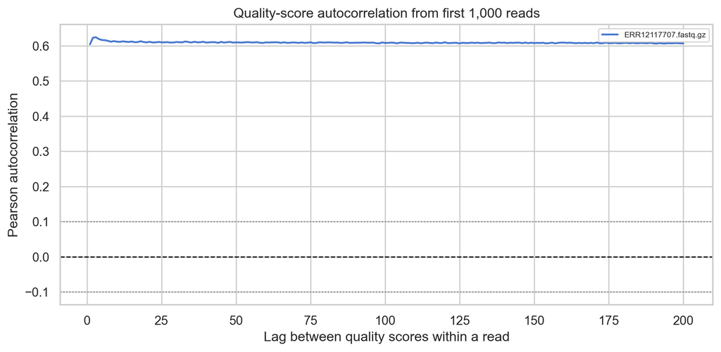

```python
if quality_summaries:
    fig, ax = plt.subplots(figsize=(9, 4.5))
    for summary in quality_summaries:
        autocorr = summary["autocorr"]
        ax.plot(
            autocorr["lag"],
            autocorr["autocorrelation"],
            linewidth=1.6,
            label=summary["file"],
        )

    ax.axhline(0.0, color="black", linestyle="--", linewidth=1)
    ax.axhline(0.10, color="gray", linestyle=":", linewidth=1)
    ax.axhline(-0.10, color="gray", linestyle=":", linewidth=1)
    ax.set_xlabel("Lag between quality scores within a read")
    ax.set_ylabel("Pearson autocorrelation")
    ax.set_title(f"Quality-score autocorrelation from first {FASTQ_SAMPLE_READS:,} reads")
    ax.legend(fontsize=7)
    plt.tight_layout()
    plt.show()
```

## 8 Read Position

This section uses `*.summary_read_position.csv`. Skiver reports error rates by distance from the start and from the end of each read. These plots help identify end-of-read degradation, adapter/trimming artifacts, or platform-specific quality decay that is not visible from value-window position alone.

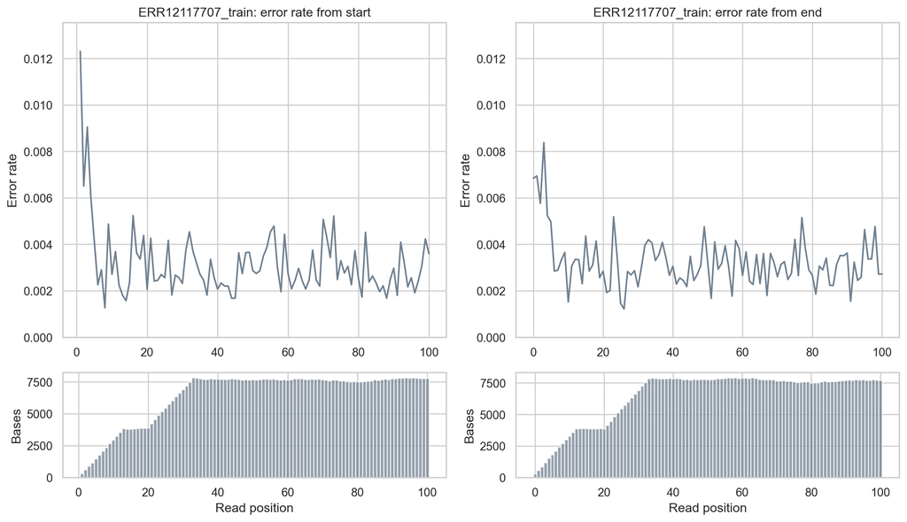

```python
def plot_read_position(prefix: Path, num_bases: int = 100) -> None:
    df = read_csv(prefix, "read_position").copy()
    df["num_total"] = df["num_correct"] + df["num_error"]
    df_start = df[df["from_start"] == True].sort_values("index")
    df_end = df[df["from_start"] == False].sort_values("index")
    df_start = df_start[df_start["index"] <= num_bases]
    df_end = df_end[df_end["index"] <= num_bases]

    fig, axes = plt.subplots(2, 2, figsize=(12, 7), gridspec_kw={"height_ratios": [3, 1]})
    max_y = max(df_start["error_rate"].max(), df_end["error_rate"].max()) * 1.1

    for col, (sub, label) in enumerate([(df_start, "from start"), (df_end, "from end")]):
        ax_line = axes[0, col]
        ax_bar = axes[1, col]
        ax_line.plot(sub["index"], sub["error_rate"], color="slategray", linewidth=1.5)
        ax_line.set_title(f"{prefix.name}: error rate {label}")
        ax_line.set_ylabel("Error rate")
        ax_line.set_ylim(0, max_y if np.isfinite(max_y) and max_y > 0 else 1)

        ax_bar.bar(sub["index"], sub["num_total"], width=1.0, color="slategray", alpha=0.75)
        ax_bar.set_xlabel("Read position")
        ax_bar.set_ylabel("Bases")

    plt.tight_layout()
    plt.show()


for prefix in PREFIXES:
    plot_read_position(prefix)
```

## 9 Error Spectrum

This section uses `*.summary_error_spectrum.csv`. It shows which substitutions and indels dominate the inferred errors, scaled by the fitted Skiver error rate. The spectrum is useful for distinguishing platform-specific modes, such as substitution-heavy Illumina errors versus indel-heavy long-read errors.

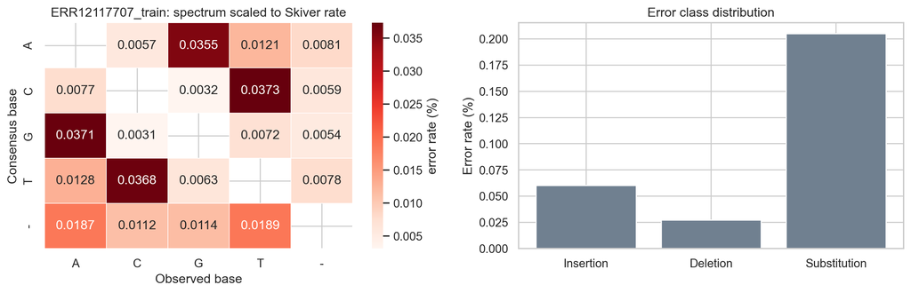

```python
def build_spectrum_matrix(df: pd.DataFrame, count_col: str = "total") -> pd.DataFrame:
    matrix = pd.DataFrame(0.0, index=BASES5, columns=BASES5)
    for _, row in df.iterrows():
        from_base, to_base = row["operation"].split(">")
        from_base = from_base if from_base in BASES5 else "-"
        to_base = to_base if to_base in BASES5 else "-"
        matrix.loc[from_base, to_base] += row[count_col]
    return matrix


def error_type_counts(df: pd.DataFrame, count_col: str = "total") -> pd.Series:
    typed = df.copy()
    typed["type"] = typed["operation"].apply(classify_op)
    return typed.groupby("type")[count_col].sum().reindex(["Insertion", "Deletion", "Substitution"], fill_value=0)


for prefix in PREFIXES:
    spectrum = read_csv(prefix, "spectrum")
    rate = read_csv(prefix, "error_rate")["per_base_error_rate"].iloc[0]
    matrix = build_spectrum_matrix(spectrum, "total")
    if matrix.values.sum() > 0:
        matrix_rate = matrix / matrix.values.sum() * rate * 100
    else:
        matrix_rate = matrix

    fig, axes = plt.subplots(1, 2, figsize=(12, 4))
    sns.heatmap(
        matrix_rate,
        annot=True,
        fmt=".4f",
        cmap="Reds",
        mask=np.eye(len(BASES5), dtype=bool),
        linewidths=0.5,
        cbar_kws={"label": "error rate (%)"},
        ax=axes[0],
    )
    axes[0].set_xlabel("Observed base")
    axes[0].set_ylabel("Consensus base")
    axes[0].set_title(f"{prefix.name}: spectrum scaled to Skiver rate")

    type_counts = error_type_counts(spectrum, "total")
    type_rates = type_counts / type_counts.sum() * rate * 100 if type_counts.sum() else type_counts
    axes[1].bar(type_rates.index, type_rates.values, color="slategray")
    axes[1].set_ylabel("Error rate (%)")
    axes[1].set_title("Error class distribution")

    plt.tight_layout()
    plt.show()
```

## 10 Homopolymer Error Context

This section uses the streamed `*.base_observations.tsv` summaries to ask whether error classes are more frequent after runs of the same nucleotide. Repeat context is event-inclusive: deleting one base from `AAA` is counted as context `3`, and inserting an `A` after `AA` is also counted as context `3`. Contexts are exact run lengths from `1` to `10`; longer runs are excluded from this context-specific summary rather than folded into a catch-all bin. The denominator is the number of consensus-base opportunities in each context, so elevated insertion or deletion rates indicate that errors are concentrated around homopolymers rather than spread evenly across sequence contexts.

```python
homopolymer_tables = []
for summary in base_summaries:
    if not summary["available"]:
        continue
    homopolymer = summary["homopolymer"].copy()
    homopolymer.insert(0, "prefix", summary["prefix"])
    homopolymer_tables.append(homopolymer)

if homopolymer_tables:
    homopolymer_df = pd.concat(homopolymer_tables, ignore_index=True)
    display(homopolymer_df)
else:
    homopolymer_df = pd.DataFrame()
    print("No base observations available for homopolymer error-context analysis.")
```

|  | prefix | repeat_context | opportunities | insertion_count | insertion_rate | deletion_count | deletion_rate | substitution_count | substitution_rate | all_error_count | all_error_rate |
| --- | --- | --- | --- | --- | --- | --- | --- | --- | --- | --- | --- |
| 0 | ERR12117707_train | 1 | 30643786 | 1594 | 0.000052 | 424 | 0.000014 | 39145 | 0.001277 | 41163 | 0.001343 |
| 1 | ERR12117707_train | 2 | 8000193 | 4380 | 0.000547 | 2944 | 0.000368 | 9007 | 0.001126 | 16331 | 0.002041 |
| 2 | ERR12117707_train | 3 | 2114091 | 3948 | 0.001867 | 1871 | 0.000885 | 2328 | 0.001101 | 8147 | 0.003854 |
| 3 | ERR12117707_train | 4 | 622310 | 2585 | 0.004154 | 886 | 0.001424 | 713 | 0.001146 | 4184 | 0.006723 |
| 4 | ERR12117707_train | 5 | 194713 | 1398 | 0.007180 | 480 | 0.002465 | 170 | 0.000873 | 2048 | 0.010518 |
| 5 | ERR12117707_train | 6 | 60737 | 856 | 0.014094 | 233 | 0.003836 | 68 | 0.001120 | 1157 | 0.019049 |
| 6 | ERR12117707_train | 7 | 16543 | 469 | 0.028350 | 90 | 0.005440 | 12 | 0.000725 | 571 | 0.034516 |
| 7 | ERR12117707_train | 8 | 3774 | 228 | 0.060413 | 39 | 0.010334 | 8 | 0.002120 | 275 | 0.072867 |
| 8 | ERR12117707_train | 9 | 366 | 61 | 0.166667 | 7 | 0.019126 | 6 | 0.016393 | 74 | 0.202186 |
| 9 | ERR12117707_train | 10 | 22 | 5 | 0.227273 | 1 | 0.045455 | 0 | 0.000000 | 6 | 0.272727 |

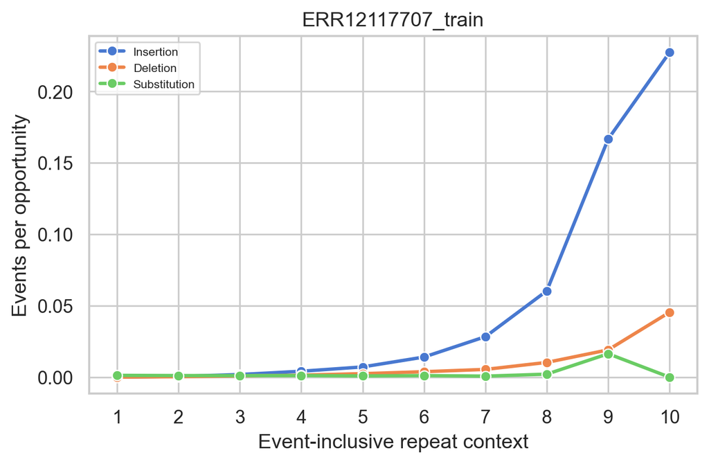

```python
if not homopolymer_df.empty:
    plot_rows = []
    for _, row in homopolymer_df.iterrows():
        for error_class in HOMOPOLYMER_ERROR_CLASSES:
            plot_rows.append({
                "prefix": row["prefix"],
                "repeat_context": row["repeat_context"],
                "error_class": error_class,
                "rate": row[f"{error_class.lower()}_rate"],
                "count": row[f"{error_class.lower()}_count"],
                "opportunities": row["opportunities"],
            })
    homopolymer_plot_df = pd.DataFrame(plot_rows)

    fig, axes = plt.subplots(1, len(PREFIXES), figsize=(6 * len(PREFIXES), 4), squeeze=False)
    for ax, (prefix, sub) in zip(axes.ravel(), homopolymer_plot_df.groupby("prefix")):
        sns.lineplot(
            data=sub,
            x="repeat_context",
            y="rate",
            hue="error_class",
            marker="o",
            linewidth=2,
            ax=ax,
        )
        ax.set_xlabel("Event-inclusive repeat context")
        ax.set_ylabel("Events per opportunity")
        ax.set_title(prefix)
        ax.legend(fontsize=7)

    plt.tight_layout()
    plt.show()
```

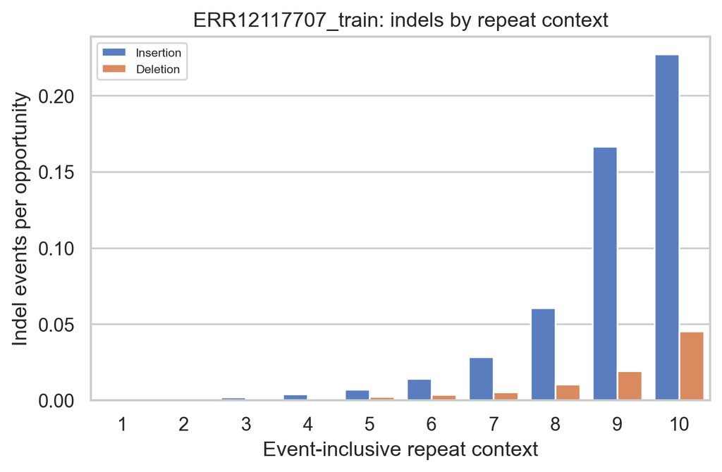

```python
if not homopolymer_df.empty:
    indel_plot_df = homopolymer_plot_df[homopolymer_plot_df["error_class"].isin(["Insertion", "Deletion"])]

    fig, axes = plt.subplots(1, len(PREFIXES), figsize=(6 * len(PREFIXES), 4), squeeze=False)
    for ax, (prefix, sub) in zip(axes.ravel(), indel_plot_df.groupby("prefix")):
        sns.barplot(
            data=sub,
            x="repeat_context",
            y="rate",
            hue="error_class",
            ax=ax,
        )
        ax.set_xlabel("Event-inclusive repeat context")
        ax.set_ylabel("Indel events per opportunity")
        ax.set_title(f"{prefix}: indels by repeat context")
        ax.legend(fontsize=7)

    plt.tight_layout()
    plt.show()
```

## 11 Spectrum Vs Value Position

This section uses `*.summary_error_spectrum_dependence_on_t.csv`. It breaks the error spectrum down by position inside the value window. Position-specific shifts in insertion, deletion, or substitution composition can indicate that the error process is not constant across the survival window.

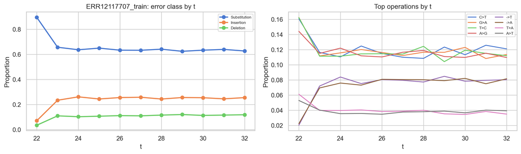

```python
for prefix in PREFIXES:
    dep = read_csv(prefix, "spectrum_t").copy()
    pos_cols = [c for c in dep.columns if c.startswith("freq_at_t")]
    positions = [int(c.split("t")[-1]) for c in pos_cols]
    dep["type"] = dep["operation"].apply(classify_op)
    totals = dep[pos_cols].sum(axis=0)
    valid_cols = [c for c in pos_cols if totals[c] > 0]
    valid_positions = [positions[pos_cols.index(c)] for c in valid_cols]

    fig, axes = plt.subplots(1, 2, figsize=(13, 4))
    for etype in ["Substitution", "Insertion", "Deletion"]:
        counts = dep.loc[dep["type"] == etype, valid_cols].sum(axis=0)
        denom = totals[valid_cols].replace(0, np.nan)
        axes[0].plot(valid_positions, counts / denom, marker="o", linewidth=2, label=etype)

    axes[0].set_xlabel("t")
    axes[0].set_ylabel("Proportion")
    axes[0].set_title(f"{prefix.name}: error class by t")
    axes[0].legend(fontsize=7)

    top_ops = dep.groupby("operation")["total"].sum().sort_values(ascending=False).head(8).index
    for op in top_ops:
        counts = dep.loc[dep["operation"] == op, valid_cols].sum(axis=0)
        denom = totals[valid_cols].replace(0, np.nan)
        axes[1].plot(valid_positions, counts / denom, linewidth=1.5, label=op)

    axes[1].set_xlabel("t")
    axes[1].set_ylabel("Proportion")
    axes[1].set_title("Top operations by t")
    axes[1].legend(fontsize=7, ncol=2)

    plt.tight_layout()
    plt.show()
```

## 12 Coverage And Filtering

This section uses `*.kvmer.csv`, with one row per key. The pass/fail counts show how many keys survive Skiver’s outlier filtering, while the coverage histograms show the distribution of total observations and consensus-supporting observations per key. Heavy tails or many low-coverage keys affect how much reliable consensus information is available.

|  | prefix |
| --- | --- |
| 0 | ERR12117707_train |

|  | passes_filter | num_keys |
| --- | --- | --- |
| 0 | True | 223916 |
| 1 | False | 78821 |

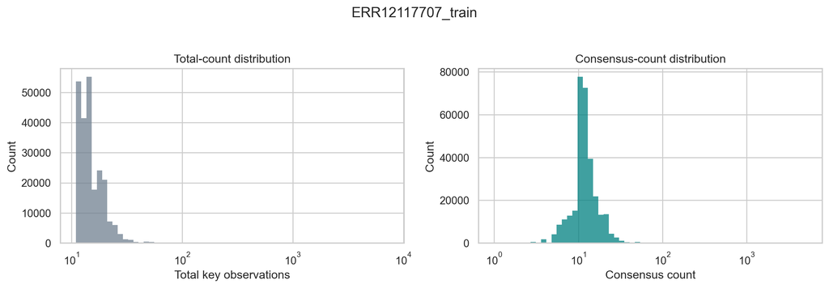

```python
def positive_log_bins(values: pd.Series, bins: int = 60) -> np.ndarray | int:
    positive = pd.Series(values).dropna()
    positive = positive[positive > 0]
    if positive.empty:
        return bins
    if positive.min() == positive.max():
        return bins
    return np.logspace(np.log10(positive.min()), np.log10(positive.max()), bins + 1)


for prefix in PREFIXES:
    kv = read_csv(prefix, "kvmer")
    pass_counts = kv["passes_filter"].value_counts(dropna=False).rename_axis("passes_filter").reset_index(name="num_keys")
    display(pd.DataFrame({"prefix": [prefix.name]}))
    display(pass_counts)

    fig, axes = plt.subplots(1, 2, figsize=(12, 4))
    sns.histplot(kv["total_count"], bins=positive_log_bins(kv["total_count"]), ax=axes[0], color="slategray")
    axes[0].set_xscale("log")
    axes[0].set_xlabel("Total key observations")
    axes[0].set_title("Total-count distribution")

    sns.histplot(kv["consensus_count"], bins=positive_log_bins(kv["consensus_count"]), ax=axes[1], color="teal")
    axes[1].set_xscale("log")
    axes[1].set_xlabel("Consensus count")
    axes[1].set_title("Consensus-count distribution")

    plt.suptitle(prefix.name, y=1.03)
    plt.tight_layout()
    plt.show()
```